# Improving convergence, 1

Peter Ralph

Sun Sep 27 20:18:30 2026

```r
fig.dim <- 4
knitr::opts_chunk$set(fig.width=2*fig.dim,
                      fig.height=fig.dim,
                      fig.align='center')
```

# The Problem

In the file mice_and_foxes2.tsv we have (fake) data consisting of the total number of mice and foxes on a certain large island across 100 years. We’re fitting a *Lotka-Volterra*-type model to these data, in which mice reproduce, but are eaten by foxes, and fox reproduction rate depends on how many mice they eat. Skipping over a lot of details, we’d like to fit the following model of how next year’s numbers of mice ($M_{t+1}$) and foxes ($F_{t+1}$) depend on the current year’s numbers ($M_t$ and $F_t$):
$$\begin{aligned}
r_t &= \exp(- \epsilon F_t) \\
M_{t+1} &\sim \Poisson( (\lambda + r_t) M_t ) \\
F_{t+1} &\sim \Poisson( p F_t + \gamma (1 - r_t) M_t ) .
\end{aligned}$$
In this model, the parameters are:

- $r = \exp(-\epsilon F)$ is the chance that a mouse escapes all foxes when there are $F$ foxes, and so
- $\epsilon$ is the per fox encounter rate, scaled
- $\lambda$ is the per capita mouse fecundity
- $p$ is the probability of survival until the next year for each fox
- $\gamma$ is the conversion rate from mice eaten to baby foxes

```
##
## rstan version 2.32.7 (Stan version 2.32.2)
```

[output not shown]

We’ll test the model on some simulated data: it will be very helpful in debugging what’s going to know what the true set of parameters is!

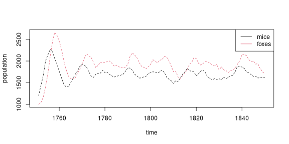

```r
sim_params <- list(
                   lambda = 0.85, # prey fecundity per year
                   lsurv = 0.4,   # predator survival prob
                   erate = .001,     # pred-prey encounter rate
                   conv = 0.8,    # prey->pred conversion rate
                   T = 100  # number of time steps
               )

set.seed(123)
MF <- run_sim(c(1200, 1000), sim_params)

matplot(MF$year, MF[,2:3], type='l', xlab='time', ylab='population', lty=2)
legend("topright", lty=1, col=1:2, legend=c("mice", "foxes"))
```

And, here’s a Stan model - this is just copied from above, with some Normal priors. (The reason for e.g. `vM` is that `M` is an integer array, as it must be, to have a Poisson distribution, so when we use `M` in the expression for the Poisson’s mean we need to convert it to a vector.)

```r
pp_block <- "
data {
    int N;
    int M[N];
    int F[N];
}
parameters {
    real<lower=0> lambda;
    real<lower=0, upper=1> lsurv;
    real<lower=0> erate;
    real<lower=0> conv;
}
model {
    vector[N-1] vM;
    vector[N-1] vF;
    vector[N-1] er;
    vM = to_vector(M[1:(N-1)]);
    vF = to_vector(F[1:(N-1)]);
    er = exp(-erate * vF);
    M[2:N] ~ poisson((lambda + er) .* vM);
    F[2:N] ~ poisson(lsurv * vF + conv * (1-er) .* vM);
    lambda ~ normal(0, 1);
    erate ~ normal(0, 1);
    conv ~ normal(0, 1);
}
"
pp_model <- stan_model(model_code=pp_block)
```

[output not shown]

Now, we’ll fit the model.

```r
pp_fit <- sampling(pp_model,
                   data=list(N=nrow(MF),
                             M=MF$mice,
                             F=MF$foxes),
                   iter=1000, chains=4,
                   control=list(max_treedepth=12))
```

[output not shown]

```r
rstan::summary(pp_fit)$summary
```

[output not shown]

```r
stan_trace(pp_fit, pars=c("lambda", "lsurv", "erate", "conv", "lp__"))
```

[output not shown]

[output not shown]

```r
stan_trace(pp_fit, pars=c("lambda", "lsurv", "erate", "conv", "lp__"), inc_warmup=TRUE)
```

[output not shown]

[output not shown]

But, how to fix it? Often, you want to look for a parameter that *isn’t moving*. Here, that’s `erate`, for chain 3. The true value of `erate` is very small: 0.001, so it’s unsurprising that chain 3 has gone right down by erate=zero and stayed there. But why haven’t the other chains got there? It helps to know some specifics about how Stan explores parameter space. Recall that `erate` is nonnegative:

```
    real<lower=0> erate;
```

It’s awkward to keep a random walk from going over an arbitrary boundary, so under the hood Stan does its exploration in [*unconstrained space*](https://mc-stan.org/docs/2_25/reference-manual/variable-transforms-chapter.html), which it gets to by a transformation. For a parameter that is constrained to be nonnegative, it just [takes a logarithm](https://mc-stan.org/docs/2_25/reference-manual/lower-bound-transform-section.html): so, it’s trying out different values of `log(erate)`. By default, it starts at locations [chosen uniformly between -2 and 2](https://mc-stan.org/docs/2_25/reference-manual/general-config-section.html#system-random-initialization) in the unconstrained space. So, it’s choosing starting locations for `erate` between `exp(-2) =` 0.1353353 and `exp(2) =` 7.3890561. These are pretty far away from the true value of 0.001.

So, we might be able to fix this by initializing the chains to start closer to zero. But, it’s a general rule of thumb in numerical work that Everything is Nicer when All the Numbers are of Order One. So, instead we might *rescale* `erate` by a factor of 1000 - in other words, decide that the natural units for it are “per 1,000 foxes” instead of “per fox”. This requires only a small change to the Stan code:

```r
pp_block2 <- "
data {
    int N;
    int M[N];
    int F[N];
}
parameters {
    real<lower=0> lambda;
    real<lower=0, upper=1> lsurv;
    real<lower=0> erate;
    real<lower=0> conv;
}
model {
    vector[N-1] vM;
    vector[N-1] vF;
    vector[N-1] er;
    vM = to_vector(M[1:(N-1)]);
    vF = to_vector(F[1:(N-1)]);
    er = exp(-erate * vF / 1000);  // RESCALED HERE
    M[2:N] ~ poisson((lambda + er) .* vM);
    F[2:N] ~ poisson(lsurv * vF + conv * (1-er) .* vM);
    lambda ~ normal(0, 1);
    erate ~ normal(0, 1);
    conv ~ normal(0, 1);
}
"
pp_model2 <- stan_model(model_code=pp_block2)
```

[output not shown]

```r
pp_fit2 <- sampling(pp_model2,
                   data=list(N=nrow(MF),
                             M=MF$mice,
                             F=MF$foxes),
                   iter=1000, chains=4,
                   control=list(max_treedepth=12))
```

[output not shown]

```r
rstan::summary(pp_fit2)$summary
```

[output not shown]

If we were to dig into this more, it’d be nice to know *why* there’s multiple likelihood maxima: what was it about that other bit of parameter space that looked good to chains 1, 2, and 4? Unfortunately, this sort of thing is a fairly general feature of dynamical systems like this, especially if changing some parameters can make the predicted dynamics zip off to infinity. Also note that in practice we won’t know what the true values of parameters are, but we can often get an idea of the right order of magnitue, which is all we needed.